# Ford Gobike Trips Exploration

## by Reem Osama El-Telbani

## Investigation Overview

> In this investigation, i wanted to look at what affects the ride trip's duration from different point of views.

## Dataset Overview

> The dataset contains 183412 rides with 16 attributes about the ride trip like, trip's duration, start_time, end_time, start station, end station. and some informations about the user like, wether the user is a subscriber or a customer, the age of users, and their gender as well. 8,826 datapoints were removed from the analysis because of the missing values or duplications.

## Distribution of Trips Duration

> Trips duration in the dataset distribution are very right skewed. as most of the people tends to not go for a too long rides

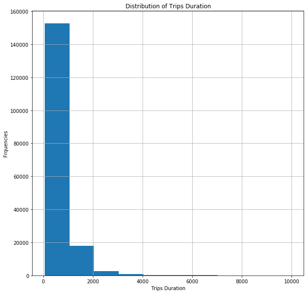

```python
indx_duration=df[df["duration_sec"]>10000].index

'''-------------Dropping Rows that contains outlaiers in duration----------------'''
df.drop(indx_duration , inplace=True)

df["duration_sec"].hist(figsize=(10,10))
plt.title('Distribution of Trips Duration')
plt.xlabel('Trips Duration')
plt.ylabel('Frquencies')
plt.show()
```

## Distribution of User Ages

> User Ages distributions are right skewed not to much. it showes that people between 20 and 50 ages rides more often than the other ages.

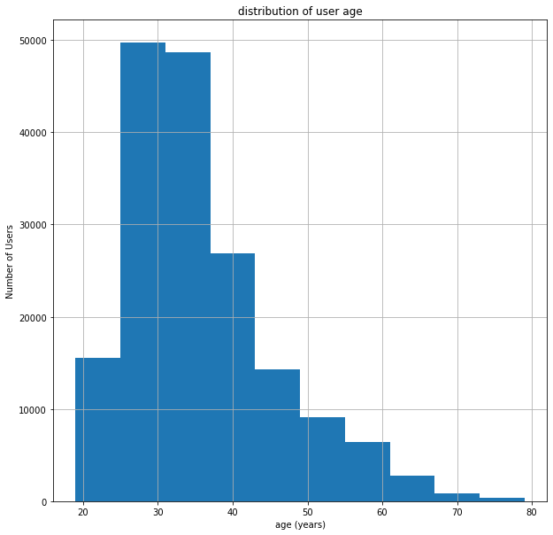

```python
indx_ages=df[df["age"]>80].index
'''-------------Dropping Rows that contains outlaiers in ages----------------'''
df.drop(indx_ages , inplace=True)


df['age'].hist(figsize=(10,10))
plt.title('distribution of user age')
plt.xlabel('age (years)')
plt.ylabel('Number of Users')
plt.show()
```

## Trips Duration and Age with respect to User Type

> the two user types seems to have the same trends in both the customer and subcribes with respect of age and trips durations. The age of the customers also have small ages than the subscribers ones.

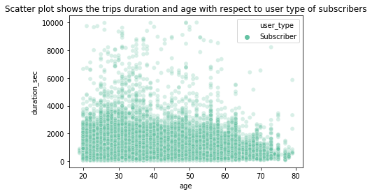

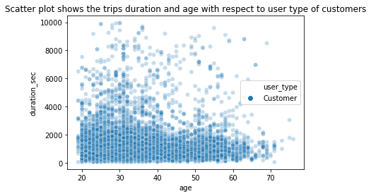

```python
df_sub = df[df["user_type"] == 'Subscriber']
df_cus = df[df["user_type"] == 'Customer']

sns.scatterplot(x='age', y = 'duration_sec', data = df_sub, hue = 'user_type', palette='BuGn', alpha=0.25)
plt.title('Scatter plot shows the trips duration and age with respect to user type of subscribers')
plt.show()
sns.scatterplot(x='age', y = 'duration_sec', data = df_cus, hue = 'user_type', alpha=0.25)
plt.title('Scatter plot shows the trips duration and age with respect to user type of customers')
plt.show()
```